# Life Projection — A Guided Tour of the World Model

For readers who have never seen this project before

Generated by the Life Projection pipeline

May 25, 2026

# A note for the reader

This notebook is meant for someone who has **never seen this project before** and who is **not a data scientist or statistician**. It does not assume you know what a “data panel,” a “percentile rank,” or a “weighted average” is. Wherever a piece of jargon appears, it is introduced in plain language first, and every chart is followed by a plain-English reading of what it does and does not say.

The notebook is long, but it is built up gradually:

- **Part A** explains what this project is trying to do, what the data is, where it comes from, and what each piece of it means.
- **Part B** walks through, step by step with real numbers, how a single measurement turns into the kind of score the rest of the notebook uses.
- **Part C** is the actual exploration — looking at coverage, sanity checking the inputs, examining how the pieces fit together, and describing what the world looks like in this dataset.
- **Part D** is honest about everything the model cannot do, and what would have to change for it to do those things.

If you only have a few minutes, read Part A, skim the headings of Part B, and then jump to **Section C5** (“Where is the world heading?”), which is the most direct payoff of the whole pipeline.

# Part A — What is this, and what is the data?

# A1. What is this project trying to do?

The Life Projection project is, at its heart, an attempt to build a **numerical portrait of every country in the world, in every year since 2000**. The idea is that if you can describe each country with a consistent set of measurements — how healthy people are, how rich the country is, how free the political system is, how stable the society is, and so on — then you can do useful things with that portrait:

1. **Compare countries to each other** in a structured way.
2. **Watch how each country changes over time.**
3. **Identify which countries are improving, deteriorating, or stagnating** on each dimension.

The eventual ambition — explicitly *not* what this notebook does — is to use that picture as scaffolding for thinking about how a person’s life might unfold given the country they live in. That is a long way off. This notebook is just about whether the picture itself is reasonable.

## What “the data” is, in one sentence

The data is a giant spreadsheet where **every row is one country, in one year, on one measurement**. So if there are about 200 countries, 25 years of data (2000 through today), and 40 different measurements, you end up with on the order of 200 × 25 × 40 = **200,000 rows**.

That’s it. That’s the whole dataset. The rest of the project is just ways of turning that long thin spreadsheet into something interpretable — averages, rankings, trends, summaries.

# A2. Where does the data come from?

Every number in this project comes from one of two free, public, internationally-respected sources. We do not collect any data ourselves; we are downloading what these institutions have already gathered and published.

## A2.1 The World Bank

The [World Bank](https://data.worldbank.org/) maintains the largest publicly available database of country-level statistics in the world. Most of its numbers are not collected by the World Bank itself. Instead, the World Bank acts as a **clearinghouse**: it gathers data that individual countries’ national statistics agencies produce (the U.S. Bureau of Labor Statistics, India’s National Sample Survey Organisation, Germany’s Destatis, etc.), standardizes the formatting and definitions across countries, and republishes them through a free public web service called an **API**.

Concretely, in this project, the script `01_fetch_data.R` makes a request to a World Bank web address that looks like:

```
https://api.worldbank.org/v2/country/all/indicator/SP.DYN.LE00.IN
```

The code at the end of that URL — `SP.DYN.LE00.IN` — is the World Bank’s internal name for “Life expectancy at birth, total (years).” The server responds with a long list of (country, year, value) records, which we then save to disk as a CSV file.

**What the World Bank typically gives us** in this project:

- Economic indicators: GDP per person, GDP growth, inflation, unemployment, savings rate, government debt
- Demographic indicators: birth rate, life expectancy, urbanization
- Health: infant mortality, hospital beds, vaccination rates
- Technology: internet users, mobile phone subscriptions
- Climate-adjacent: CO2 emissions per person, energy use per person

**How was this data originally collected?** It varies enormously by indicator and by country. A few examples to make this concrete:

- *Life expectancy* comes from death certificates and population censuses. A country’s statistical office calculates, “If a baby born today experienced the death rates we observed at every age this year, how long would they live on average?” The World Bank then publishes that single number per country, per year.
- *Internet users (% of population)* comes from household surveys conducted by the International Telecommunication Union (a UN agency) and by national statistics offices, asking, “Has anyone in this household used the internet in the last three months?”
- *Inflation (consumer price index)* comes from monthly price collection visits to thousands of shops in each country by government statisticians who literally write down what a loaf of bread, a litre of milk, etc. cost, and then aggregate.
- *CO2 emissions per person* comes from energy-use data and factory output data, multiplied by chemical conversion factors, then divided by the country’s population.

This range matters because **data quality varies wildly**. A rich country with a long-established statistics agency (Germany, Japan) produces a very different quality of inflation number from a country in active conflict (Syria, Yemen) where statisticians can’t safely visit shops. The numbers all *look* the same when you put them in a spreadsheet — but they are not the same.

## A2.2 Our World In Data (OWID)

[Our World In Data](https://ourworldindata.org) is a research project based at the University of Oxford that does something similar to the World Bank but for **academic and specialty datasets**. Where the World Bank focuses on official government statistics, OWID republishes datasets that come from research institutes, academic projects, and international agencies that don’t have their own public API.

In this project, OWID is the source for two important things:

1. **V-Dem democracy indices.** V-Dem (“Varieties of Democracy”) is a research project at the University of Gothenburg, Sweden. They send detailed questionnaires to country experts — typically political scientists who specialize in a particular country — asking 470 questions about the political situation in that country in that year. Are elections clean? Can opposition parties operate? Does the judiciary actually act independently of the government? Each question is answered on a numeric scale, and the answers are aggregated into composite indices like *liberal democracy index*, *electoral democracy index*, *rule of law*, and so on. These are the most rigorous quantitative measurements of governance we have.
2. **Specialty climate, health, and emissions data** that the World Bank does not publish, or publishes less reliably.

OWID is fetched in the same script (`01_fetch_data.R`), through a different URL pattern. Each OWID dataset has a “slug” name and is downloaded as a CSV.

## A2.3 What we are *not* using (and why it matters)

There is one important source that we wanted but do not have: **ACLED** (Armed Conflict Location & Event Data). ACLED is the gold standard for fine-grained data on political violence — battle deaths, protests, riots, attacks on civilians — but it requires an institutional research license that this project does not have. As a substitute, we use V-Dem’s “rule of law” and “control of corruption” indices as proxies for stability, which is **not the same thing** as direct measures of violence and is one of the model’s most important limitations.

A free alternative, **UCDP** (Uppsala Conflict Data Program), is downloadable as CSVs without an API key and could be added as a follow-up to repair this gap.

# A3. What is the structure of the data?

This section is hands-on. We are going to look at literal rows of the actual data we use, because that is the fastest way to develop a feel for what’s in here.

## A3.1 One row at a time

After all the downloading and combining, the master table looks like this. Here are the first ten rows of the data for the United States:

```r
panel |>
  filter(country_iso3 == "USA") |>
  left_join(indicators |> select(indicator, unit, source), by = "indicator") |>
  arrange(year, indicator) |>
  head(10) |>
  select(country_iso3, year, indicator, value, unit, source) |>
  kable(caption = "First 10 rows of the data, for the USA. Each row is one country, one year, one measurement. (unit and source come from the indicator registry — they are properties of the indicator, not the observation, so they aren't repeated in the panel itself.)")
```

First 10 rows of the data, for the USA. Each row is one country, one year, one measurement. (unit and source come from the indicator registry — they are properties of the indicator, not the observation, so they aren’t repeated in the panel itself.)

| country_iso3 | year | indicator | value | unit | source |
| --- | --- | --- | --- | --- | --- |
| USA | 2000 | co2_per_capita | 21.397860 | tonnes_per_capita | owid |
| USA | 2000 | deliberative_democracy_index | 0.808000 | index_0_1 | owid |
| USA | 2000 | dependency_ratio | 50.035833 | percent | worldbank |
| USA | 2000 | electoral_democracy_index | 0.867000 | index_0_1 | owid |
| USA | 2000 | female_labor_participation | 58.682000 | percent | worldbank |
| USA | 2000 | fertility_rate | 2.056000 | births_per_woman | worldbank |
| USA | 2000 | forest_area_share | 33.130174 | percent_land | worldbank |
| USA | 2000 | freedom_of_association_index | 0.941000 | index_0_1 | owid |
| USA | 2000 | freedom_of_expression_index | 0.962000 | index_0_1 | owid |
| USA | 2000 | gdp_growth | 4.077586 | percent | worldbank |

Reading the first row: in the year **2000**, the **United States** had a value for the indicator **`co2_per_capita`** measured in the unit **tonnes**. That single number came from **OWID**’s emissions dataset. The next row is the same year, same country, a different indicator. And so on.

This format — one measurement per row — is sometimes called **long format**. It is the format that scales: adding a new indicator means adding more rows, not new columns. Tables like this can have hundreds of thousands of rows but only six or seven columns.

The full panel in this run contains **181,837 rows** across **232 countries** and **41 indicators**, from **2000** to **2025**.

## A3.2 What identifies a country?

You may have noticed the column `country_iso3` instead of just a country name. Country names are a *mess* in data work — is it “Republic of Korea,” “South Korea,” “Korea, Rep.,” “Korea (Republic of)”? Different sources use different conventions, which makes joining tables painful.

To get around this, every country in the world has an **ISO 3166-1 alpha-3 code**: a three-letter identifier that is the same everywhere.

```r
tibble::tribble(
  ~country,                ~iso3,
  "United States",         "USA",
  "Germany",               "DEU",
  "Japan",                 "JPN",
  "China",                 "CHN",
  "India",                 "IND",
  "Brazil",                "BRA",
  "South Africa",          "ZAF",
  "United Kingdom",        "GBR",
  "Republic of Korea",     "KOR",
  "Democratic Rep. Congo", "COD"
) |>
  kable(caption = "Country names are inconsistent across sources; ISO3 codes are not.")
```

Country names are inconsistent across sources; ISO3 codes are not.

| country | iso3 |
| --- | --- |
| United States | USA |
| Germany | DEU |
| Japan | JPN |
| China | CHN |
| India | IND |
| Brazil | BRA |
| South Africa | ZAF |
| United Kingdom | GBR |
| Republic of Korea | KOR |
| Democratic Rep. Congo | COD |

Throughout this notebook, when you see codes like `USA` or `DEU`, those are countries.

## A3.3 What is an “indicator”?

An **indicator** is just our internal name for one measurable thing — “life expectancy at birth,” “GDP per person in constant 2015 US dollars,” “share of population with internet access,” and so on.

Each indicator has a small profile recorded in a configuration file called `indicators.csv`, which tells the pipeline:

- which source to fetch it from (World Bank or OWID),
- what the source’s internal name for it is,
- which **module** it belongs to (more on modules in a moment),
- what unit it’s measured in,
- whether higher numbers are better or worse,
- and how much weight it should carry inside its module.

Here are a few example rows from that configuration:

```r
indicators |>
  filter(indicator %in% c("life_expectancy", "gdp_per_capita_ppp",
                          "infant_mortality", "co2_per_capita",
                          "liberal_democracy_index", "internet_users_share")) |>
  select(module, indicator, source, source_id, unit, direction, weight) |>
  arrange(module) |>
  kable(caption = "A few example indicator definitions, including their within-module weights.")
```

A few example indicator definitions, including their within-module weights.

| module | indicator | source | source_id | unit | direction | weight |
| --- | --- | --- | --- | --- | --- | --- |
| climate | co2_per_capita | owid | co-emissions-per-capita | tonnes_per_capita | lower_is_better | 0.25 |
| economy | gdp_per_capita_ppp | worldbank | NY.GDP.PCAP.PP.KD | constant_2021_intl_dollars | higher_is_better | 0.30 |
| health | life_expectancy | worldbank | SP.DYN.LE00.IN | years | higher_is_better | 0.30 |
| health | infant_mortality | worldbank | SP.DYN.IMRT.IN | per_1000_live_births | lower_is_better | 0.20 |
| rights | liberal_democracy_index | owid | liberal-democracy-index | index_0_1 | higher_is_better | 0.25 |
| technology | internet_users_share | owid | share-of-individuals-using-the-internet | percent | higher_is_better | 0.30 |

That `direction` column matters a lot. For something like life expectancy, **higher is better**. For something like infant mortality, **lower is better** — a country with infant mortality of 3 per 1,000 births is doing better than one at 50 per 1,000. Later in the pipeline, when we standardize all indicators onto a common scale, the `lower_is_better` ones get *flipped* so that “higher = better” everywhere. This makes module scores interpretable.

The `weight` column is used much later, in **Step B4**, when individual indicator scores are combined into module-level scorecards. Some indicators are considered more central to their module than others (life expectancy gets more weight than hospital beds inside the health module, for example), and the weight column encodes that judgement. Weights inside a module can be written on any convenient scale — the pipeline renormalises them to sum to 1 before averaging.

## A3.4 What is a “module”?

40+ individual indicators is too many for a human to look at all at once. So we group them into **eight thematic modules**:

```r
indicators |>
  count(module, name = "n_indicators") |>
  arrange(desc(n_indicators)) |>
  kable(caption = "The eight modules and how many indicators each contains.")
```

The eight modules and how many indicators each contains.

| module | n_indicators |
| --- | --- |
| economy | 8 |
| rights | 7 |
| health | 6 |
| climate | 5 |
| labor | 5 |
| demographics | 4 |
| stability | 4 |
| technology | 4 |

You can think of each module as a **scorecard subject** for a country, the way a school report card has subjects (Math, English, Science). The eight subjects here are:

| Module | What it tries to measure | Example indicators |
| --- | --- | --- |
| **economy** | How the economy is doing | GDP per person, growth, inflation, debt |
| **labor** | Quality of the job market | Unemployment, labor force participation |
| **health** | Population health | Life expectancy, infant mortality, hospital capacity |
| **demographics** | Population structure | Birth rate, urbanization, age structure |
| **rights** | Political and civil rights | V-Dem democracy and rights indices |
| **stability** | Governance and rule of law | V-Dem rule-of-law and corruption indices |
| **climate** | Environmental footprint | CO2 per person, energy intensity |
| **technology** | Technological development | Internet, mobile, R&D spending |

The full list of every indicator and which module it belongs to is shown in **Section C1.1**.

## A3.5 So what does one country look like overall?

```r
panel |>
  filter(country_iso3 == "USA", year == max(year[country_iso3 == "USA"])) |>
  left_join(indicators |> select(indicator, module, unit), by = "indicator") |>
  arrange(module, indicator) |>
  select(module, indicator, value, unit) |>
  head(15) |>
  kable(caption = "Sample of the most-recent year of USA data, showing how indicators slot into modules.")
```

Sample of the most-recent year of USA data, showing how indicators slot into modules.

| module | indicator | value | unit |
| --- | --- | --- | --- |
| climate | renewable_electricity_share | 25.63836 | percent |
| labor | female_labor_participation | 56.34300 | percent |
| labor | labor_force_participation | 61.70400 | percent |
| labor | unemployment_rate | 4.19800 | percent |
| labor | vulnerable_employment | 3.80977 | percent |
| labor | youth_unemployment_rate | 9.34000 | percent |
| rights | deliberative_democracy_index | 0.48100 | index_0_1 |
| rights | electoral_democracy_index | 0.73500 | index_0_1 |
| rights | freedom_of_association_index | 0.91300 | index_0_1 |
| rights | freedom_of_expression_index | 0.72900 | index_0_1 |
| rights | liberal_democracy_index | 0.57100 | index_0_1 |
| rights | participatory_democracy_index | 0.51000 | index_0_1 |
| stability | judicial_constraints_executive | 0.84400 | index_0_1 |
| stability | liberal_component_index | 0.75400 | index_0_1 |
| stability | political_corruption_index | 0.06000 | index_0_1 |

Every other country gets the same treatment, every year from 2000 onward, subject to whether the data was actually reported.

# Part B — From raw data to finished scores, traced step by step

This section is the “show your work” section. We are going to take **one country and one indicator** and follow them all the way from the moment the World Bank’s server sends us a number, to the moment that number becomes part of the United States’ final scorecard.

If you only read one part of this notebook to understand how the pipeline actually works, read this section.

# B1. Step 1 — The raw response from the source

The pipeline starts by making a web request to the World Bank API. When we ask for life expectancy data, the server replies with something that looks roughly like this (simplified for readability):

```
{
  "countryiso3code": "USA",
  "date": "2022",
  "value": 77.4280487804878,
  "indicator": { "id": "SP.DYN.LE00.IN", "value": "Life expectancy at birth" }
}
{
  "countryiso3code": "USA",
  "date": "2021",
  "value": 76.3329268292683,
  "indicator": { "id": "SP.DYN.LE00.IN", "value": "Life expectancy at birth" }
}
... (and so on, for every country and every year)
```

This is **JSON** — a common format for data on the web. The pipeline parses it, throws away the metadata it doesn’t need, and saves a small CSV with just three columns:

What the raw CSV looks like for one indicator (life expectancy). One row per country-year.

| country_iso3 | year | value |
| --- | --- | --- |
| USA | 2020 | 77.000 |
| USA | 2021 | 76.333 |
| USA | 2022 | 77.428 |
| DEU | 2020 | 81.100 |
| DEU | 2021 | 80.900 |
| DEU | 2022 | 80.700 |
| JPN | 2020 | 84.620 |
| JPN | 2021 | 84.530 |
| JPN | 2022 | 84.020 |
| … | NA | NA |

There is now one such CSV file on disk for **every indicator** — about 40 of them in this project. That is what “fetching the raw data” amounts to.

# B2. Step 2 — Combining all indicators into one panel

Each of the 40 raw CSV files contains the same three columns (`country_iso3`, `year`, `value`) but for a different measurement. The next step (in `02_combine_process.R`) is to stack them all together, tagging each row with which indicator it represents.

After this step the data, joined with the relevant metadata for display, looks like this:

```r
panel |>
  filter(country_iso3 == "USA", year == 2020,
         indicator %in% c("life_expectancy", "gdp_per_capita_ppp",
                          "infant_mortality", "internet_users_share",
                          "co2_per_capita")) |>
  left_join(indicators |> select(indicator, module, unit), by = "indicator") |>
  arrange(indicator) |>
  select(country_iso3, year, indicator, value, unit, module) |>
  kable(caption = "After combining: one row per country-year-indicator. Module and unit come from the indicator registry — they're properties of the indicator, not the observation, so they live in indicators.csv and get joined on when needed.")
```

After combining: one row per country-year-indicator. Module and unit come from the indicator registry — they’re properties of the indicator, not the observation, so they live in indicators.csv and get joined on when needed.

| country_iso3 | year | indicator | value | unit | module |
| --- | --- | --- | --- | --- | --- |
| USA | 2020 | co2_per_capita | 13.81690 | tonnes_per_capita | climate |
| USA | 2020 | gdp_per_capita_ppp | 67342.07093 | constant_2021_intl_dollars | economy |
| USA | 2020 | infant_mortality | 5.50000 | per_1000_live_births | health |
| USA | 2020 | internet_users_share | 90.34470 | percent | technology |
| USA | 2020 | life_expectancy | 76.98049 | years | health |

Five separate downloaded files have become five rows of one big spreadsheet. Multiply this by all 200 countries and all 25 years and all 40 indicators, and you get the master panel — about 182,000 rows in this run.

# B3. Step 3 — Why raw values cannot be averaged directly

Here is the central problem this project has to solve:

> **You cannot meaningfully average life expectancy (a number around 80) with GDP per person (a number around 60,000) with the rule of law index (a number between 0 and 1).** They are in totally different units and on totally different scales.

If you just took the average, GDP per person would completely dominate, and the answer would be roughly “GDP per person divided by the number of indicators.” The other measurements would be lost.

To combine indicators into a sensible score, we first have to put them on a **common scale**. The pipeline uses two different ways of doing this, and computes both for every measurement.

## B3.1 Method 1 — Where do you rank against everyone *this year*?

The first method is called `pct_global` in the data. It asks: **In this specific year, where does this country rank against all other countries on this specific indicator?**

The result is a number from 0 to 100, where:

- 0 means you are the worst country in the world this year on this measure
- 50 means you are exactly in the middle
- 100 means you are the best country in the world this year on this measure

This is called a **percentile rank**. It is the same logic as a child’s height percentile at a pediatrician’s office: “90th percentile for height” means 90% of children that age are shorter.

**A worked example.** Let’s say in 2022 there are 180 countries with life expectancy data, and the United States’ life expectancy of 77.4 years ranks 35th from the top (well behind Japan, Switzerland, Singapore, etc., but ahead of most of the world). Then USA’s `pct_global` for life expectancy that year would be:

```
(180 - 35) / 180 × 100 = 80.6
```

So the USA scores about **81 out of 100** on life expectancy *relative to the rest of the world in 2022*.

**Why is this useful?** It tells you about your country’s *position in the global pecking order*. A score of 80 means “I’m doing better than 80% of countries this year.” That’s intuitive and useful.

**Why is this not enough?** Imagine that next year, *every country in the world* gets dramatically less healthy — life expectancy drops by 5 years everywhere. The USA would still rank 35th out of 180, and would still get a `pct_global` of 80. The score wouldn’t move, even though the world got worse. **Percentile ranks can’t show global movement** — if everyone moves together, the rankings stay the same.

## B3.2 Method 2 — Where do you sit against the all-time global scale?

The second method is called `pct_fixed`. Instead of comparing you to the other countries *this year*, it compares your value to the **all-time range** that this indicator has ever taken across all countries since 2000.

Specifically:

```
pct_fixed = (your value − all-time global minimum) /
            (all-time global maximum − all-time global minimum)
            × 100
```

This is called **min-max scaling**. It also produces a number from 0 to 100, but the meaning is different:

- 0 means you match the all-time worst on this indicator
- 100 means you match the all-time best on this indicator
- 50 means you are exactly halfway between the worst and best

**A worked example.** Life expectancy across all countries since 2000 ranges from about 38 years (worst, in a country during a catastrophic period) to about 85 years (best, places like Japan and Monaco in recent years). The USA’s 77.4 years in 2022 would be:

```
(77.4 − 38) / (85 − 38) × 100  =  83.8
```

So the USA scores **about 84 out of 100** on the all-time global scale.

**Why is this useful?** Unlike `pct_global`, this version *can* detect global movement. If life expectancy collapses worldwide, the denominator stays fixed at the historical range, and everyone’s score genuinely falls.

The pipeline computes **both** scaled versions for every measurement. Different questions need different scales.

## B3.3 Handling “lower is better” indicators

One more subtlety. Some indicators are good when they go down (infant mortality, inflation, CO2 emissions per person) and some are good when they go up (life expectancy, GDP per person).

When we scale them, we want **higher = better in every case**, because otherwise averaging them is incoherent. So for the “lower is better” ones, we flip the score:

```
flipped_score = 100 − original_score
```

That is what the `direction` field in the indicator configuration controls. After the flip, **a score of 80 always means “doing well”** regardless of whether the underlying indicator was infant mortality or life expectancy.

## B3.4 What the data looks like after Step 3

So now every original row has gained two new columns. Here is the USA in 2020 again, this time with the scaled values:

```r
normalized |>
  filter(country_iso3 == "USA", year == 2020,
         indicator %in% c("life_expectancy", "gdp_per_capita_ppp",
                          "infant_mortality", "internet_users_share",
                          "co2_per_capita")) |>
  left_join(indicators |> select(indicator, direction), by = "indicator") |>
  arrange(indicator) |>
  select(country_iso3, year, indicator, value, direction, pct_global, pct_fixed) |>
  mutate(across(c(pct_global, pct_fixed), \(x) round(x, 1))) |>
  kable(caption = "After scaling: every raw value has both a per-year ranking (pct_global) and an all-time-scale value (pct_fixed). Both are 0–100 with higher = better.")
```

After scaling: every raw value has both a per-year ranking (pct_global) and an all-time-scale value (pct_fixed). Both are 0–100 with higher = better.

| country_iso3 | year | indicator | value | direction | pct_global | pct_fixed |
| --- | --- | --- | --- | --- | --- | --- |
| USA | 2020 | co2_per_capita | 13.81690 | lower_is_better | 6.1 | 98.2 |
| USA | 2020 | gdp_per_capita_ppp | 67342.07093 | higher_is_better | 95.0 | 38.3 |
| USA | 2020 | infant_mortality | 5.50000 | lower_is_better | 73.7 | 98.2 |
| USA | 2020 | internet_users_share | 90.34470 | higher_is_better | 83.9 | 90.3 |
| USA | 2020 | life_expectancy | 76.98049 | higher_is_better | 69.6 | 86.8 |

Each of these scaled scores is now directly comparable across indicators. A `pct_fixed` of 80 on life expectancy and a `pct_fixed` of 80 on internet access both mean “doing 80% of the way from the all-time global worst to the all-time global best.” They can now be averaged together meaningfully.

# B4. Step 4 — Combining indicators into module scores

Now that all indicators are on the same 0–100 scale, we can combine them into the eight module scorecards.

For each module, the pipeline takes a **weighted average** of its indicator scores. The weights live in the same `indicators.csv` registry described in A3.3 — each indicator has a `weight` column saying how much it should count inside its module. Some indicators are considered more central to a module than others, so they count more. The pipeline renormalises the per-module weights so they sum to 1 before averaging, which means you can write the raw weights on any convenient scale.

For example, the **health** module might be weighted like this (values shown are proportions that sum to 1.0):

```r
weights |>
  filter(module == "health") |>
  arrange(desc(weight)) |>
  mutate(weight = round(weight, 3)) |>
  kable(caption = "Example: weights for indicators inside the 'health' module. They sum to 1.0.")
```

Example: weights for indicators inside the ‘health’ module. They sum to 1.0.

| module | indicator | weight |
| --- | --- | --- |
| health | life_expectancy | 0.30 |
| health | infant_mortality | 0.20 |
| health | maternal_mortality | 0.15 |
| health | health_expenditure_pct_gdp | 0.15 |
| health | physicians_per_1000 | 0.10 |
| health | hospital_beds_per_1000 | 0.10 |

For a given country and year, the health module score is computed as:

```
health_score = (life_expectancy_score × weight1) +
               (infant_mortality_score × weight2) +
               (hospital_beds_score × weight3) + ...
```

This is repeated for all eight modules.

**One important detail — missing data.** Not every country reports every indicator every year. If a country is missing, say, the “hospital beds per 1,000 people” measurement, the pipeline does not treat it as zero (which would be wrong). Instead, it computes the weighted average **only over the indicators that are present**, and records a `coverage` number that tells you what fraction of the module’s expected indicators were available. A health score computed from 5 out of 7 expected indicators has `coverage = 0.71` and is more uncertain than one computed from 7 out of 7.

After this step, the data is now much shorter — one row per country, per year, per module. Here is the USA’s full set of 2020 module scores:

```r
scores |>
  filter(country_iso3 == "USA", year == 2020) |>
  arrange(desc(score_pct_fixed)) |>
  select(country_iso3, year, module, score_pct_fixed, score_pct_global,
         contributing_count, expected_count, coverage) |>
  mutate(across(c(score_pct_fixed, score_pct_global, coverage), \(x) round(x, 2))) |>
  kable(caption = "The United States' eight module scores for 2020. coverage = how many of the module's expected indicators were available.")
```

The United States’ eight module scores for 2020. coverage = how many of the module’s expected indicators were available.

| country_iso3 | year | module | score_pct_fixed | score_pct_global | contributing_count | expected_count | coverage |
| --- | --- | --- | --- | --- | --- | --- | --- |
| USA | 2020 | stability | 92.86 | 85.92 | 4 | 4 | 1.00 |
| USA | 2020 | rights | 83.85 | 83.37 | 6 | 7 | 0.86 |
| USA | 2020 | labor | 75.40 | 56.42 | 5 | 5 | 1.00 |
| USA | 2020 | health | 75.34 | 73.56 | 6 | 6 | 1.00 |
| USA | 2020 | climate | 66.71 | 46.77 | 4 | 5 | 0.80 |
| USA | 2020 | economy | 56.43 | 60.28 | 8 | 8 | 1.00 |
| USA | 2020 | technology | 51.06 | 81.19 | 4 | 4 | 1.00 |
| USA | 2020 | demographics | 50.66 | 52.35 | 4 | 4 | 1.00 |

This is, in compact form, the United States’ “world model” entry for the year 2020.

# B5. Step 5 — Trajectories: where is the country heading?

Module scores tell you where a country *is* in a given year. But the more interesting question is often *where it is going*. The final step of the pipeline computes a trajectory summary for every country and module.

For each (country, module), we look at the last 5 years of scores and ask:

1. **Level**: what is the most recent score?
2. **Trend**: is it going up or down, and how fast?
3. **Volatility**: is it stable, or jumping around?

The trend is computed by drawing a straight line through the last five yearly scores and reading off its slope. (For readers familiar with statistics, this is an ordinary least squares regression of score on year. For everyone else: imagine the five yearly scores as five dots on a graph, drawing a line that fits them best, and asking whether the line goes up or down and how steeply.)

The slope is measured in **points per year on the 0–100 scale**:

- A slope of **+1.5** means “the score is rising by 1.5 points per year, so after a decade it will be 15 points higher.”
- A slope of **−2.0** means “the score is falling by 2 points per year.”

Based on the slope and volatility, every (country, module) gets labeled with one of five **flags**:

| Flag | Meaning |
| --- | --- |
| **improving** | Trend ≥ +1 point per year. Clearly moving up. |
| **deteriorating** | Trend ≤ −1 point per year. Clearly moving down. |
| **volatile** | No clear trend, but the score has been bouncing around (std dev > 5). |
| **stable** | Small or no movement, low volatility. |
| **insufficient_data** | Fewer than 3 years of data. Can’t tell. |

Here is the USA’s full trajectory summary:

```r
trajectories |>
  filter(country_iso3 == "USA") |>
  arrange(desc(level)) |>
  select(country_iso3, module, latest_year, level, trend_5y, trend_10y,
         volatility_5y, flag) |>
  mutate(across(c(level, trend_5y, trend_10y, volatility_5y), \(x) round(x, 2))) |>
  kable(caption = "The United States' trajectory across all eight modules. 'level' is where the country is now; 'trend_5y' is how fast it has been moving over the last five years.")
```

The United States’ trajectory across all eight modules. ‘level’ is where the country is now; ‘trend_5y’ is how fast it has been moving over the last five years.

| country_iso3 | module | latest_year | level | trend_5y | trend_10y | volatility_5y | flag |
| --- | --- | --- | --- | --- | --- | --- | --- |
| USA | health | 2024 | 92.93 | 4.84 | 0.98 | 8.71 | improving |
| USA | stability | 2025 | 87.05 | -1.69 | -0.35 | 3.39 | deteriorating |
| USA | labor | 2025 | 80.06 | 0.21 | 0.07 | 0.86 | stable |
| USA | rights | 2025 | 71.27 | -3.23 | -0.89 | 7.58 | deteriorating |
| USA | economy | 2024 | 57.37 | 0.12 | 0.22 | 0.51 | stable |
| USA | demographics | 2024 | 50.20 | -0.10 | -0.27 | 0.18 | stable |
| USA | climate | 2025 | 25.64 | -5.40 | -2.69 | 15.38 | deteriorating |
| USA | technology | 2024 | 23.29 | -5.44 | -0.67 | 12.86 | deteriorating |

This is the final compressed output: one summary row per country per module, capturing where they are and where they’re heading.

# B6. Recap — the three outputs

The pipeline produces three files on disk, mapping directly to sections B1–B5:

| File | Produced by step | What’s in it |
| --- | --- | --- |
| `country_year_indicators.csv` | B1–B3 | Long panel: country, year, indicator, raw value, plus the two scaled columns (`pct_global`, `pct_fixed`). |
| `country_year_scores.csv` | B4 | Module composites: 8 modules × ~200 countries × 25 years. |
| `country_trajectories.csv` | B5 | One trajectory row per country per module. |

The indicator panel is intentionally slim — six columns. Indicator metadata (which module, which unit, which source, direction) lives once in `config/indicators.csv` rather than being repeated on every row of the panel. The notebook joins on indicator metadata wherever it’s needed.

Sections **C1–C6** below explore these three files and ask whether the picture they paint is reasonable.

# Part C — Exploring the world the data describes

This is where the rest of the notebook used to start. With the groundwork in Parts A and B in place, we can now actually look at the data and ask things like: is the coverage good? Do the measurements make sense? What does the world look like in 2025? Where is it heading?

# C1. What did we manage to collect?

This first section is a **stock-take**. Before drawing any conclusions from the data, we want to know what is in it: which indicators we successfully fetched, which years are well-covered, and which countries have enough data to be reasoned about.

## C1.1 The complete indicator inventory

Here is every individual indicator the pipeline tracks, grouped by module.

```r
indicators |>
  arrange(module, indicator) |>
  select(module, indicator, source, unit, direction, weight, description) |>
  kable(caption = "Every indicator in the pipeline. 'direction' tells us which way is 'better' before scaling; 'source' tells us where the number originally came from; 'weight' tells us how much the indicator contributes to its module score (weights are renormalised per module).")
```

Every indicator in the pipeline. ‘direction’ tells us which way is ‘better’ before scaling; ‘source’ tells us where the number originally came from; ‘weight’ tells us how much the indicator contributes to its module score (weights are renormalised per module).

| module | indicator | source | unit | direction | weight | description |
| --- | --- | --- | --- | --- | --- | --- |
| climate | air_pollution_death_rate | owid | per_100k | lower_is_better | 0.20 | Death rate from air pollution (OWID) |
| climate | co2_per_capita | owid | tonnes_per_capita | lower_is_better | 0.25 | CO2 emissions per capita (OWID) |
| climate | forest_area_share | worldbank | percent_land | higher_is_better | 0.15 | Forest area (% land) |
| climate | pm25_exposure | worldbank | ug_per_m3 | lower_is_better | 0.20 | PM2.5 mean annual exposure |
| climate | renewable_electricity_share | owid | percent | higher_is_better | 0.20 | Renewable electricity share (OWID) |
| demographics | dependency_ratio | worldbank | percent | lower_is_better | 0.40 | Age dependency ratio (% working-age) |
| demographics | fertility_rate | worldbank | births_per_woman | higher_is_better | 0.20 | Fertility rate (births per woman) |
| demographics | population_growth | worldbank | percent | higher_is_better | 0.20 | Population growth (annual %) |
| demographics | urban_population_share | worldbank | percent | higher_is_better | 0.20 | Urban population (% of total) |
| economy | gdp_growth | worldbank | percent | higher_is_better | 0.10 | GDP growth (annual %) |
| economy | gdp_per_capita_ppp | worldbank | constant_2021_intl_dollars | higher_is_better | 0.30 | GDP per capita PPP (constant 2021 intl $) |
| economy | gini_index | worldbank | index_0_100 | lower_is_better | 0.15 | Gini income inequality |
| economy | gross_capital_formation_pct_gdp | worldbank | percent_gdp | higher_is_better | 0.05 | Gross capital formation (% GDP) |
| economy | gross_savings_pct_gdp | worldbank | percent_gdp | higher_is_better | 0.05 | Gross savings (% GDP) |
| economy | inflation_cpi | worldbank | percent | lower_is_better | 0.10 | Inflation consumer prices (annual %) |
| economy | poverty_headcount_ratio | worldbank | percent | lower_is_better | 0.20 | Poverty headcount $2.15/day |
| economy | trade_pct_gdp | worldbank | percent_gdp | higher_is_better | 0.05 | Trade as % of GDP |
| health | health_expenditure_pct_gdp | worldbank | percent_gdp | higher_is_better | 0.15 | Current health expenditure (% GDP) |
| health | hospital_beds_per_1000 | worldbank | per_1000_people | higher_is_better | 0.10 | Hospital beds (per 1000 people) |
| health | infant_mortality | worldbank | per_1000_live_births | lower_is_better | 0.20 | Infant mortality (per 1000 live births) |
| health | life_expectancy | worldbank | years | higher_is_better | 0.30 | Life expectancy at birth (years) |
| health | maternal_mortality | worldbank | per_100k_live_births | lower_is_better | 0.15 | Maternal mortality (per 100k live births) |
| health | physicians_per_1000 | worldbank | per_1000_people | higher_is_better | 0.10 | Physicians (per 1000 people) |
| labor | female_labor_participation | worldbank | percent | higher_is_better | 0.15 | Female labor participation (% female 15+) |
| labor | labor_force_participation | worldbank | percent | higher_is_better | 0.20 | Labor force participation (% pop 15+) |
| labor | unemployment_rate | worldbank | percent | lower_is_better | 0.30 | Unemployment total (% labor force ILO) |
| labor | vulnerable_employment | worldbank | percent | lower_is_better | 0.15 | Vulnerable employment (% total employment) |
| labor | youth_unemployment_rate | worldbank | percent | lower_is_better | 0.20 | Unemployment ages 15-24 (% ILO) |
| rights | deliberative_democracy_index | owid | index_0_1 | higher_is_better | 0.10 | Deliberative democracy index (V-Dem via OWID) |
| rights | egalitarian_democracy_index | owid | index_0_1 | higher_is_better | 0.10 | Egalitarian democracy index (V-Dem via OWID) |
| rights | electoral_democracy_index | owid | index_0_1 | higher_is_better | 0.20 | Electoral democracy index (V-Dem via OWID) |
| rights | freedom_of_association_index | owid | index_0_1 | higher_is_better | 0.10 | Freedom of association index (V-Dem via OWID) |
| rights | freedom_of_expression_index | owid | index_0_1 | higher_is_better | 0.15 | Freedom of expression index (V-Dem via OWID) |
| rights | liberal_democracy_index | owid | index_0_1 | higher_is_better | 0.25 | Liberal democracy index (V-Dem via OWID) |
| rights | participatory_democracy_index | owid | index_0_1 | higher_is_better | 0.10 | Participatory democracy index (V-Dem via OWID) |
| stability | judicial_constraints_executive | owid | index_0_1 | higher_is_better | 0.25 | Judicial constraints on the executive (V-Dem via OWID) |
| stability | liberal_component_index | owid | index_0_1 | higher_is_better | 0.25 | Liberal component index (V-Dem via OWID) |
| stability | political_corruption_index | owid | index_0_1 | lower_is_better | 0.25 | Political corruption index (V-Dem via OWID; higher=more corrupt) |
| stability | rule_of_law_index | owid | index_0_1 | higher_is_better | 0.25 | Rule of law index (V-Dem via OWID) |
| technology | high_tech_exports_share | worldbank | percent_manufactured_exports | higher_is_better | 0.25 | High-technology exports (% manufactured exports) |
| technology | internet_users_share | owid | percent | higher_is_better | 0.30 | Internet users (% population, OWID) |
| technology | mobile_subscriptions | worldbank | per_100_people | higher_is_better | 0.15 | Mobile cellular subscriptions |
| technology | rd_expenditure_pct_gdp | worldbank | percent_gdp | higher_is_better | 0.30 | Research and development expenditure (% GDP) |

A quick sanity-check by source and module:

```r
indicators |>
  count(source, module) |>
  pivot_wider(names_from = source, values_from = n, values_fill = 0) |>
  arrange(module) |>
  kable(caption = "How many indicators per module come from each source.")
```

How many indicators per module come from each source.

| module | owid | worldbank |
| --- | --- | --- |
| climate | 3 | 2 |
| demographics | 0 | 4 |
| economy | 0 | 8 |
| health | 0 | 6 |
| labor | 0 | 5 |
| rights | 7 | 0 |
| stability | 4 | 0 |
| technology | 1 | 3 |

A reader-friendly takeaway: the **rights** and **stability** modules are both built almost entirely from V-Dem (via OWID), which means they will be heavily correlated and effectively measure the same underlying thing — political institutions. We’ll see this directly in **Section C3**.

## C1.2 Coverage at a glance

For each indicator, how many countries actually report a value in each year? Sparse indicators carry less weight in scoring. The right-edge fade in this heatmap is **reporting lag** — newer years have less data because countries take time to publish their statistics. That fade is *not* a meaningful trend in the world; it is a fact about data freshness.

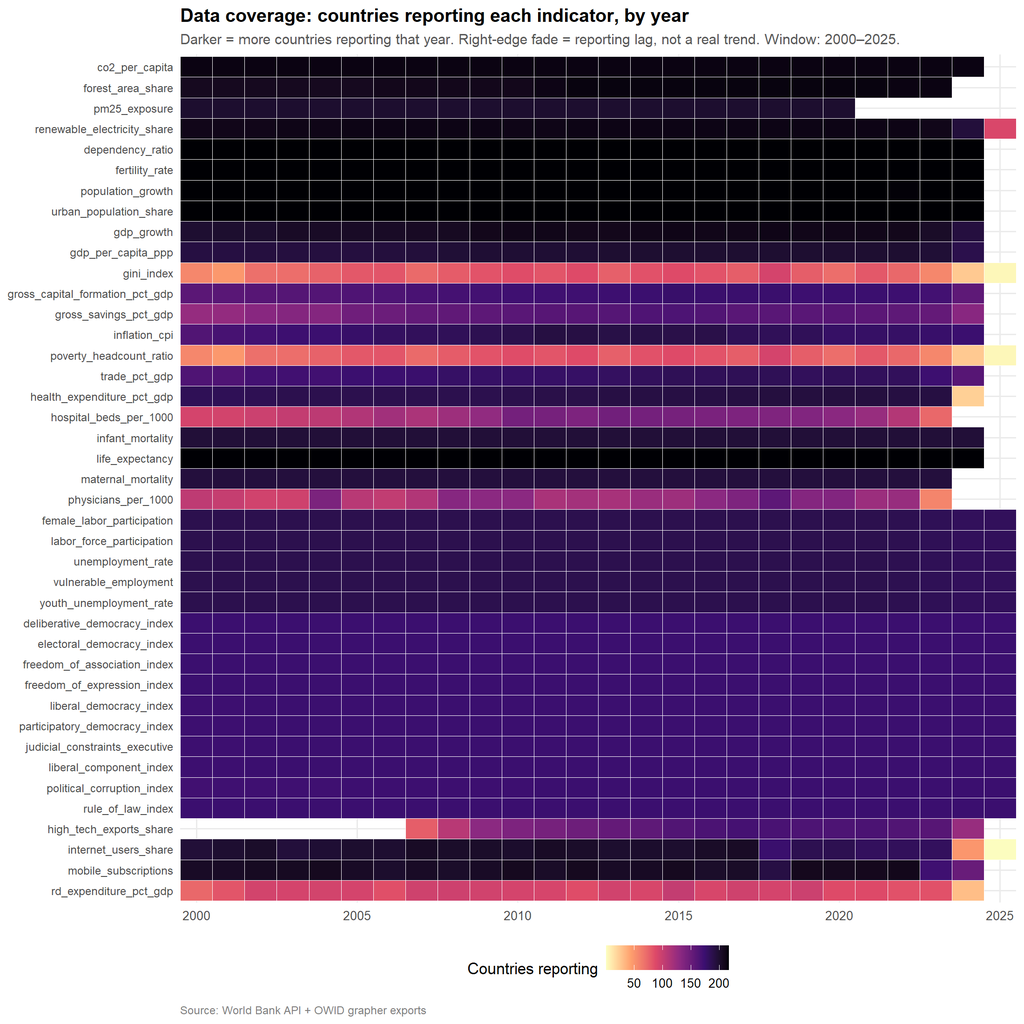

```r
coverage_grid <- panel |>
  group_by(indicator, year) |>
  summarise(n_countries = n_distinct(country_iso3), .groups = "drop") |>
  left_join(indicators |> select(indicator, module), by = "indicator")

indicator_order_by_module <- indicators |>
  arrange(module, indicator) |>
  pull(indicator)
coverage_grid <- coverage_grid |>
  mutate(indicator = factor(indicator, levels = rev(indicator_order_by_module)))

ggplot(coverage_grid, aes(year, indicator, fill = n_countries)) +
  geom_tile(color = "white", linewidth = 0.1) +
  scale_fill_viridis_c(option = "magma", direction = -1, name = "Countries reporting") +
  scale_x_continuous(breaks = seq(ANALYSIS_START_YEAR, max(panel$year), by = 5),
                     limits = c(ANALYSIS_START_YEAR - 0.5, max(panel$year) + 0.5),
                     expand  = c(0, 0)) +
  labs(
    title    = "Data coverage: countries reporting each indicator, by year",
    subtitle = sprintf("Darker = more countries reporting that year. Right-edge fade = reporting lag, not a real trend. Window: %d–%d.",
                       ANALYSIS_START_YEAR, max(panel$year)),
    x = NULL, y = NULL,
    caption = "Source: World Bank API + OWID grapher exports"
  ) +
  theme_lp() +
  theme(axis.text.y = element_text(size = 8))
```

## C1.3 Which countries are well-covered?

How complete is each country’s data in the last five years? A country with very few indicators reporting will have unreliable module scores.

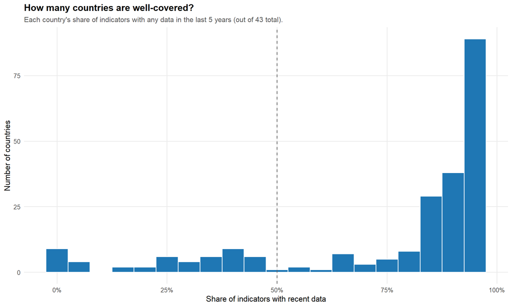

```r
country_completeness <- panel |>
  filter(year >= latest_year - 5) |>
  group_by(country_iso3) |>
  summarise(
    indicators_present = n_distinct(indicator),
    indicators_total   = nrow(indicators),
    completeness       = indicators_present / indicators_total,
    .groups = "drop"
  )

ggplot(country_completeness, aes(completeness)) +
  geom_histogram(binwidth = 0.05, fill = "#1f77b4", color = "white") +
  geom_vline(xintercept = 0.5, linetype = "dashed", color = "grey40") +
  scale_x_continuous(labels = percent_format()) +
  labs(
    title    = "How many countries are well-covered?",
    subtitle = sprintf("Each country's share of indicators with any data in the last 5 years (out of %d total).",
                       nrow(indicators)),
    x = "Share of indicators with recent data",
    y = "Number of countries"
  ) +
  theme_lp()
```

```r
cat(sprintf("Countries with at least 75%% coverage: %d\n",
            sum(country_completeness$completeness >= 0.75)))
```

```
## Countries with at least 75% coverage: 167
```

```r
cat(sprintf("Countries with less than 50%% coverage:  %d  (treat their scores as approximate)\n",
            sum(country_completeness$completeness < 0.50)))
```

```
## Countries with less than 50% coverage:  48  (treat their scores as approximate)
```

**Reading this chart:** the horizontal axis is “fraction of all indicators where this country has any recent data,” and the bars show how many countries fall in each bucket. The mass is on the right — most countries are well-covered. But a long left tail of small island states, recent conflict zones, and isolated countries (North Korea, Eritrea, etc.) drops below 50% coverage. Their module scores still exist in the output files, but every chart in this notebook that ranks countries should be read with their thin coverage in mind.

# C2. Are the inputs sane?

Before trusting any composite scores, we should sanity-check the raw indicators themselves. Two failure modes destroy the whole pipeline:

1. **Extreme outliers** — one freakish value that distorts the min-max scaling for everyone else.
2. **Broken time series** — a sudden jump in a number that reflects a methodology change at the data source, not a real-world event.

This section surfaces them.

## C2.1 Distributions of each raw indicator

For each indicator, we draw a **boxplot** showing how the value is distributed across all country-years. A boxplot is a compact summary that shows the middle 50% of values as a box, the median as a line inside, and “whiskers” reaching out to typical extremes.

The key thing to look for is indicators where the box is very thin (values clustered close together) but the whiskers stretch a long way (a few extreme outliers way out). Those are the indicators where min-max scaling will compress 95% of countries into a narrow band near 0.

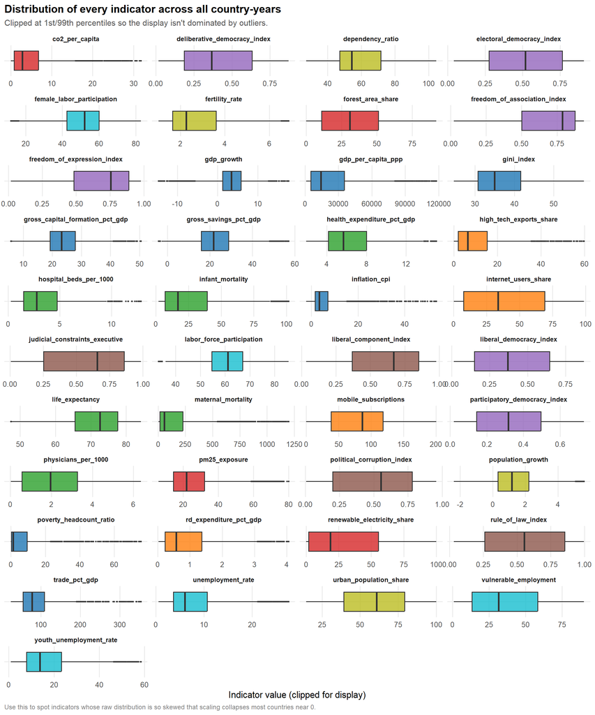

```r
panel_for_dist <- panel |>
  left_join(indicators |> select(indicator, module), by = "indicator") |>
  group_by(indicator) |>
  mutate(
    value_clip = pmin(pmax(value, quantile(value, 0.01, na.rm = TRUE)),
                                  quantile(value, 0.99, na.rm = TRUE))
  ) |>
  ungroup()

ggplot(panel_for_dist, aes(x = value_clip, y = "")) +
  geom_boxplot(aes(fill = module), outlier.size = 0.4, alpha = 0.8) +
  facet_wrap(~ indicator, scales = "free_x", ncol = 4) +
  scale_fill_manual(values = MODULE_COLORS, guide = "none") +
  labs(
    title    = "Distribution of every indicator across all country-years",
    subtitle = "Clipped at 1st/99th percentiles so the display isn't dominated by outliers.",
    x = "Indicator value (clipped for display)", y = NULL,
    caption = "Use this to spot indicators whose raw distribution is so skewed that scaling collapses most countries near 0."
  ) +
  theme_lp() +
  theme(strip.text  = element_text(size = 8),
        axis.text.y = element_blank())
```

This is a wall of small charts on purpose — the goal is to scan it quickly and spot indicators that look skewed.

## C2.2 The outlier diagnostic

A more focused look at the outlier problem. For each indicator we compute the **ratio of the maximum value to the 95th-percentile value**. A ratio of 1.2 is healthy (the maximum is a little higher than the 95th percentile, like you’d expect from a normal-ish distribution). A ratio of 50 means a tiny number of country-years sit so far above the rest that they completely dominate the upper range.

```r
outlier_check <- panel |>
  group_by(indicator) |>
  summarise(
    p50 = median(value, na.rm = TRUE),
    p95 = quantile(value, 0.95, na.rm = TRUE),
    max = max(value, na.rm = TRUE),
    max_over_p95 = max / p95,
    .groups = "drop"
  ) |>
  arrange(desc(max_over_p95)) |>
  mutate(
    flag = case_when(
      max_over_p95 > 50 ~ "CRITICAL — log transform recommended",
      max_over_p95 > 10 ~ "watch — heavy tail",
      TRUE              ~ "ok"
    )
  )

outlier_check |>
  head(15) |>
  kable(digits = 2,
        caption = "The 15 indicators with the heaviest right tails. When max/p95 > 50, a small number of country-years swallow the entire upper range of the scaled scores.")
```

The 15 indicators with the heaviest right tails. When max/p95 > 50, a small number of country-years swallow the entire upper range of the scaled scores.

| indicator | p50 | p95 | max | max_over_p95 | flag |
| --- | --- | --- | --- | --- | --- |
| inflation_cpi | 3.49 | 18.23 | 557.20 | 30.56 | watch — heavy tail |
| gross_savings_pct_gdp | 21.72 | 43.46 | 372.98 | 8.58 | ok |
| gdp_growth | 3.51 | 10.21 | 86.83 | 8.50 | ok |
| population_growth | 1.18 | 3.59 | 21.70 | 6.05 | ok |
| trade_pct_gdp | 78.02 | 174.94 | 863.20 | 4.93 | ok |
| co2_per_capita | 2.87 | 17.81 | 67.73 | 3.80 | ok |
| mobile_subscriptions | 86.55 | 156.25 | 574.15 | 3.67 | ok |
| infant_mortality | 16.90 | 76.41 | 239.90 | 3.14 | ok |
| hospital_beds_per_1000 | 2.76 | 7.88 | 22.27 | 2.83 | ok |
| high_tech_exports_share | 6.52 | 34.36 | 95.62 | 2.78 | ok |
| health_expenditure_pct_gdp | 5.68 | 11.00 | 27.09 | 2.46 | ok |
| gdp_per_capita_ppp | 14343.02 | 72390.69 | 174569.52 | 2.41 | ok |
| maternal_mortality | 58.00 | 692.50 | 1662.00 | 2.40 | ok |
| physicians_per_1000 | 1.96 | 4.56 | 9.54 | 2.09 | ok |
| rd_expenditure_pct_gdp | 0.58 | 3.14 | 6.35 | 2.02 | ok |

**The fix**, which is not yet implemented in the pipeline, is to apply a **logarithmic transformation** to these indicators before scaling — that is, take the log of each value first, which pulls the long tail back in. Or to **winsorize**, which means capping values at the 1st and 99th percentiles. Either approach would restore meaningful spread for the bulk of countries.

## C2.3 Suspect direction assignments

Recall that every indicator has a `direction` — either “higher is better” or “lower is better” — that determines whether to flip its score during scaling. Several indicators in this pipeline have a direction encoded that doesn’t survive careful scrutiny.

```r
suspect <- tibble::tribble(
  ~indicator,                ~current_direction,  ~problem,
  "fertility_rate",          "higher_is_better",  "Not universal. High fertility with low resources isn't unambiguously better.",
  "population_growth",       "higher_is_better",  "Descriptive, not normative. Many wealthy countries have negative growth by choice.",
  "urban_population_share",  "higher_is_better",  "Debatable. Hyper-urbanization brings real social and environmental costs.",
  "trade_pct_gdp",           "higher_is_better",  "Openness vs vulnerability — context-dependent.",
  "gross_savings_pct_gdp",   "higher_is_better",  "Very high savings can signal weak domestic consumption.",
  "high_tech_exports_share", "higher_is_better",  "Rewards small specialised economies. Diverse manufacturers like the USA score poorly even though they lead in absolute high-tech output."
)
kable(suspect, caption = "Indicators whose 'direction' is arguable. Their contributions to module scores should be read with care.")
```

Indicators whose ‘direction’ is arguable. Their contributions to module scores should be read with care.

| indicator | current_direction | problem |
| --- | --- | --- |
| fertility_rate | higher_is_better | Not universal. High fertility with low resources isn’t unambiguously better. |
| population_growth | higher_is_better | Descriptive, not normative. Many wealthy countries have negative growth by choice. |
| urban_population_share | higher_is_better | Debatable. Hyper-urbanization brings real social and environmental costs. |
| trade_pct_gdp | higher_is_better | Openness vs vulnerability — context-dependent. |
| gross_savings_pct_gdp | higher_is_better | Very high savings can signal weak domestic consumption. |
| high_tech_exports_share | higher_is_better | Rewards small specialised economies. Diverse manufacturers like the USA score poorly even though they lead in absolute high-tech output. |

The most consequential case is the **demographics** module. Three of its four core indicators are descriptive — they say something about a country’s population structure but don’t carry an obvious “better/worse” meaning. Encoding them as “higher is better” turns them into noise rather than signal. We will see this confirmed by hard numbers in **Section C3.2**.

# C3. Do the modules hang together?

A module score is a weighted average of its indicators. For that average to mean anything, the indicators inside the module need to **actually measure related things**.

If two indicators in the same module move in opposite directions — one going up when the other goes down — averaging them just cancels them out, like trying to find someone’s “general health” by averaging their heart rate and their height. The result is a number, but it doesn’t represent anything coherent.

Similarly, if two indicators in **different** modules move almost identically, those modules aren’t actually capturing distinct phenomena. They’re double-counting.

## C3.1 Correlation between every pair of indicators

We measure how strongly two indicators move together with a number called the **correlation coefficient**, abbreviated *r*. It ranges from −1 to +1:

- **+1.0** = the two indicators move perfectly together (when one goes up, the other always does too).
- **0** = no relationship — knowing one tells you nothing about the other.
- **−1.0** = the two indicators move perfectly *opposite* (when one goes up, the other always goes down).

In real social data, values above 0.6 are considered “strongly correlated” and below 0.3 “weak.”

Here is the correlation between every pair of indicators in the pipeline, drawn as a heatmap. Blue = positive correlation (move together). Red = negative correlation (move opposite). White = no relationship. Indicators are grouped by module, with thick black lines marking the module boundaries.

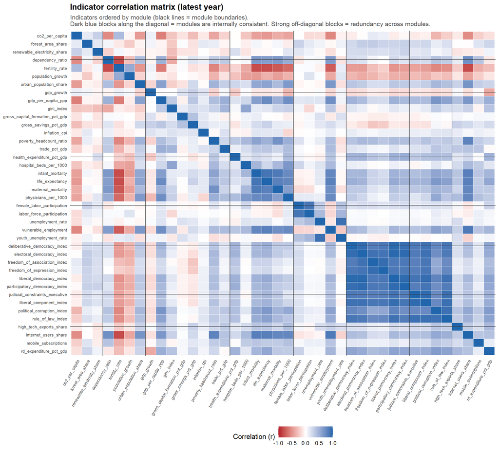

```r
latest_per_indicator <- normalized |>
  filter(year >= latest_year - 2) |>
  group_by(country_iso3, indicator) |>
  slice_max(year, n = 1) |>
  ungroup()

cor_wide <- latest_per_indicator |>
  select(country_iso3, indicator, pct_fixed) |>
  pivot_wider(names_from = indicator, values_from = pct_fixed) |>
  select(-country_iso3)

indicator_order <- indicators |>
  arrange(module, indicator) |>
  pull(indicator)
indicator_order <- intersect(indicator_order, names(cor_wide))
cor_wide        <- cor_wide[, indicator_order]

cor_mat <- cor(cor_wide, use = "pairwise.complete.obs")

cor_long <- as.data.frame(cor_mat) |>
  tibble::rownames_to_column("ind_x") |>
  pivot_longer(-ind_x, names_to = "ind_y", values_to = "r") |>
  mutate(
    ind_x = factor(ind_x, levels = indicator_order),
    ind_y = factor(ind_y, levels = rev(indicator_order))
  )

module_boundaries <- indicators |>
  filter(indicator %in% indicator_order) |>
  arrange(factor(indicator, levels = indicator_order)) |>
  mutate(rownum = row_number()) |>
  group_by(module) |>
  summarise(boundary = max(rownum) + 0.5, .groups = "drop") |>
  pull(boundary)
module_boundaries <- head(module_boundaries, -1)

ggplot(cor_long, aes(ind_x, ind_y, fill = r)) +
  geom_tile(color = "white", linewidth = 0.1) +
  geom_vline(xintercept = module_boundaries, color = "grey20", linewidth = 0.4) +
  geom_hline(yintercept = length(indicator_order) - module_boundaries + 0.5,
             color = "grey20", linewidth = 0.4) +
  scale_fill_gradient2(low = "#b2182b", mid = "white", high = "#2166ac",
                       midpoint = 0, limits = c(-1, 1), name = "Correlation (r)") +
  labs(
    title    = "Indicator correlation matrix (latest year)",
    subtitle = "Indicators ordered by module (black lines = module boundaries).\nDark blue blocks along the diagonal = modules are internally consistent. Strong off-diagonal blocks = redundancy across modules.",
    x = NULL, y = NULL
  ) +
  theme_lp() +
  theme(axis.text.x = element_text(angle = 60, hjust = 1, size = 7),
        axis.text.y = element_text(size = 7))
```

**Reading this heatmap:**

- Look at the **square blocks along the diagonal**, one per module. A module is “internally consistent” if its block is uniformly dark blue — its indicators all move together.
- Strong blue **outside the diagonal blocks** means two modules are measuring overlapping things.
- Any **red** cells flag pairs of indicators that move in opposite directions. If those two indicators are in the same module, the module’s average is incoherent.

The most obvious feature in this run is the **strong blue block where the rights module meets the stability module**. They are almost the same data (V-Dem indices), so the modules are essentially duplicating each other.

## C3.2 The module coherence summary

The heatmap is a lot to look at. Here is a single-number summary per module: the average correlation between pairs of indicators inside the module.

```r
within_module_cor <- indicators |>
  group_by(module) |>
  group_modify(~ {
    inds <- intersect(.x$indicator, names(cor_wide))
    if (length(inds) < 2) return(tibble(avg_r = NA_real_, min_r = NA_real_, n_pairs = 0))
    sub <- cor_mat[inds, inds]
    sub[upper.tri(sub, diag = TRUE)] <- NA
    vals <- as.vector(sub)
    vals <- vals[!is.na(vals)]
    tibble(avg_r = mean(vals), min_r = min(vals), n_pairs = length(vals))
  }) |>
  arrange(desc(avg_r))

kable(within_module_cor, digits = 2,
      caption = "Average and minimum correlation among indicators within each module. Negative min_r means at least one indicator pair is moving in opposite directions inside the module.")
```

Average and minimum correlation among indicators within each module. Negative min_r means at least one indicator pair is moving in opposite directions inside the module.

| module | avg_r | min_r | n_pairs |
| --- | --- | --- | --- |
| rights | 0.91 | 0.84 | 15 |
| stability | 0.87 | 0.74 | 6 |
| health | 0.50 | 0.09 | 15 |
| technology | 0.30 | 0.11 | 6 |
| labor | 0.27 | -0.25 | 10 |
| climate | 0.18 | 0.12 | 3 |
| economy | 0.17 | -0.21 | 28 |
| demographics | -0.15 | -0.83 | 6 |

**Reading this table:**

- `avg_r` is the average correlation between every pair of indicators inside the module. Higher is better — it means the indicators agree with each other.
- `min_r` is the *worst* correlation — the most disagreeing pair. If this is below 0, then at least one indicator in the module is actively pulling against the others.

**Recommendation**: drop the `demographics` *score*. Keep its indicators (they are useful individually as context — knowing a country’s age structure matters), but don’t try to average them into a composite. The composite is misleading.

# C4. What does the world look like right now?

Now that we have sanity-checked the inputs, we can finally look at the headline output: what does each country’s scorecard say at present?

## C4.1 The shape of each module’s scores worldwide

For each module, here is the **distribution of scores across all countries** in the latest available year. The horizontal axis is the score (0 = all-time global worst, 100 = all-time global best). The vertical bars count how many countries fall in each bucket.

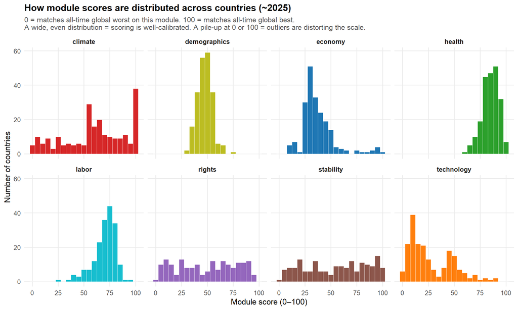

```r
latest_scores <- scores |>
  filter(year >= latest_year - 2) |>
  group_by(country_iso3, module) |>
  slice_max(year, n = 1, with_ties = FALSE) |>
  ungroup()

ggplot(latest_scores, aes(score_pct_fixed, fill = module)) +
  geom_histogram(binwidth = 5, color = "white", linewidth = 0.2) +
  facet_wrap(~ module, ncol = 4) +
  scale_fill_manual(values = MODULE_COLORS, guide = "none") +
  labs(
    title    = sprintf("How module scores are distributed across countries (~%d)", latest_year),
    subtitle = "0 = matches all-time global worst on this module. 100 = matches all-time global best.\nA wide, even distribution = scoring is well-calibrated. A pile-up at 0 or 100 = outliers are distorting the scale.",
    x = "Module score (0–100)", y = "Number of countries"
  ) +
  theme_lp()
```

## C4.2 Top 10 and Bottom 10 per module — the cheapest sanity check

If our scoring is working, the top 10 countries on rights should be Scandinavian democracies. The top 10 on health should be wealthy countries with strong healthcare systems. If something is broken upstream, this is where it screams.

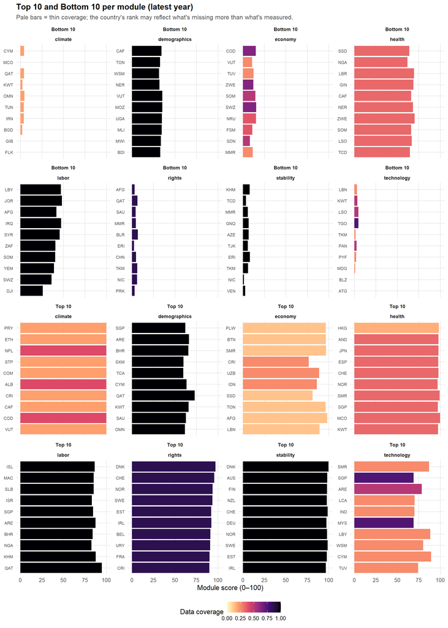

```r
top_bot <- latest_scores |>
  group_by(module) |>
  mutate(rank_top = rank(-score_pct_fixed), rank_bot = rank(score_pct_fixed)) |>
  filter(rank_top <= 10 | rank_bot <= 10) |>
  mutate(side = if_else(rank_top <= 10, "Top 10", "Bottom 10")) |>
  ungroup()

ggplot(top_bot,
       aes(x = reorder(country_iso3, score_pct_fixed),
           y = score_pct_fixed, fill = coverage)) +
  geom_col() +
  coord_flip() +
  facet_wrap(side ~ module, scales = "free_y", ncol = 4) +
  scale_fill_viridis_c(option = "magma", direction = -1,
                       limits = c(0, 1), name = "Data coverage") +
  labs(
    title    = "Top 10 and Bottom 10 per module (latest year)",
    subtitle = "Pale bars = thin coverage; the country's rank may reflect what's missing more than what's measured.",
    x = NULL, y = "Module score (0–100)"
  ) +
  theme_lp() +
  theme(axis.text.y = element_text(size = 7),
        strip.text   = element_text(size = 8))
```

The pattern is clear: **the V-Dem-based modules work; the others have indicator-design problems that need to be fixed before their scores can be trusted.**

## C4.3 The economy-vs-rights map (with caveats)

A two-dimensional scatter plot of countries on rights versus economy is a classic way to visualize the regime-type landscape: rich democracies in one corner, poor autocracies in another, and so on.

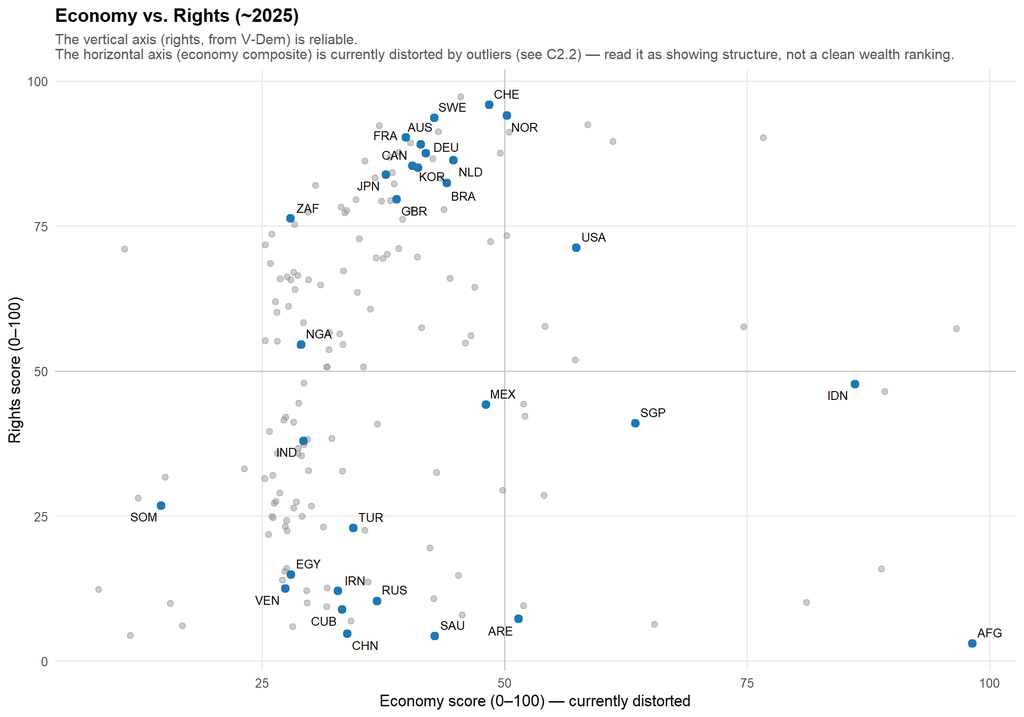

```r
econ_rights <- latest_scores |>
  filter(module %in% c("economy", "rights")) |>
  select(country_iso3, module, score_pct_fixed) |>
  pivot_wider(names_from = module, values_from = score_pct_fixed) |>
  filter(!is.na(economy), !is.na(rights))

to_label <- econ_rights |>
  filter(country_iso3 %in% c("USA","DEU","JPN","GBR","FRA","CAN","AUS","SWE","NOR",
                             "CHN","RUS","SAU","ARE","IRN","TUR","EGY",
                             "IND","BRA","ZAF","MEX","IDN","NGA",
                             "VEN","CUB","PRK","AFG","SOM","SYR",
                             "SGP","KOR","CHE","NLD"))

ggplot(econ_rights, aes(economy, rights)) +
  geom_hline(yintercept = 50, color = "grey80") +
  geom_vline(xintercept = 50, color = "grey80") +
  geom_point(color = "grey60", alpha = 0.5, size = 1.8) +
  geom_point(data = to_label, color = "#1f77b4", size = 2.5) +
  ggrepel::geom_text_repel(data = to_label, aes(label = country_iso3),
                           size = 3, max.overlaps = 50, segment.color = "grey70") +
  labs(
    title    = sprintf("Economy vs. Rights (~%d)", latest_year),
    subtitle = "The vertical axis (rights, from V-Dem) is reliable.\nThe horizontal axis (economy composite) is currently distorted by outliers (see C2.2) — read it as showing structure, not a clean wealth ranking.",
    x = "Economy score (0–100) — currently distorted",
    y = "Rights score (0–100)"
  ) +
  theme_lp()
```

**How to read this:**

- Each dot is a country. Highlighted dots are countries we’ve labeled.
- The vertical axis (rights) is the V-Dem score and is reliable — countries higher up score better on civil and political rights.
- The horizontal axis (economy) is the composite economy score and is *currently miscalibrated* because of the outlier issues documented in C2.2 — so the absolute X-position should not be read as a wealth ranking. But the *structure* of the chart still separates regime types.
- The familiar pattern emerges: Scandinavian democracies in the top region; authoritarian regimes (China, Russia, Saudi Arabia, Iran) lower down; collapsed states (Afghanistan, Somalia, Syria, Venezuela) in the bottom corners.

# C5. Where is the world heading?

This is the section that pays off the whole pipeline. We have scorecards. Now: **are the scorecards moving?**

## C5.1 Global trend, one line per module

For each module, we plot the **median country’s score** every year from 2000 to today, with a shaded band showing the middle 50% of countries (between the 25th and 75th percentile). This shows whether the typical country is improving, stagnating, or declining on each dimension — and how much variation there is.

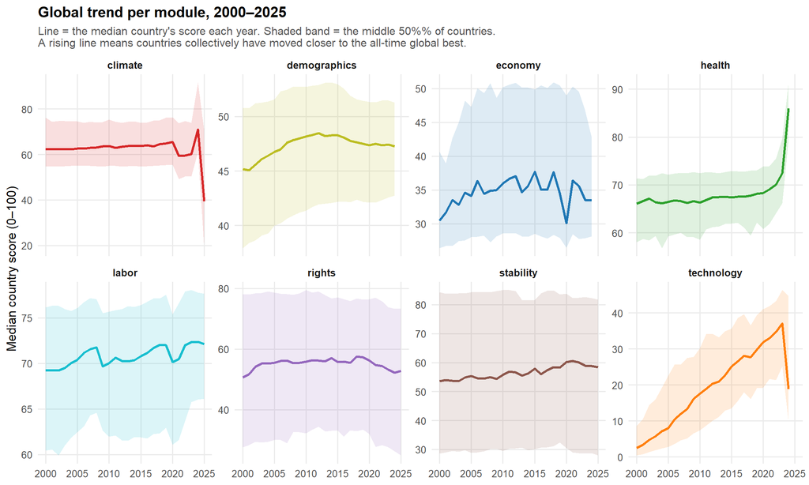

```r
global_trend <- scores |>
  group_by(module, year) |>
  summarise(
    median = median(score_pct_fixed, na.rm = TRUE),
    p25    = quantile(score_pct_fixed, 0.25, na.rm = TRUE),
    p75    = quantile(score_pct_fixed, 0.75, na.rm = TRUE),
    n      = n(),
    .groups = "drop"
  ) |>
  filter(n >= 50)  # exclude sparse years

ggplot(global_trend, aes(year, median, color = module, fill = module)) +
  geom_ribbon(aes(ymin = p25, ymax = p75), alpha = 0.15, color = NA) +
  geom_line(linewidth = 1) +
  facet_wrap(~ module, ncol = 4, scales = "free_y") +
  scale_x_continuous(limits = c(ANALYSIS_START_YEAR, max(global_trend$year)),
                     breaks = seq(ANALYSIS_START_YEAR, max(global_trend$year), by = 5)) +
  scale_color_manual(values = MODULE_COLORS, guide = "none") +
  scale_fill_manual(values  = MODULE_COLORS, guide = "none") +
  labs(
    title    = sprintf("Global trend per module, %d–%d", ANALYSIS_START_YEAR, max(global_trend$year)),
    subtitle = "Line = the median country's score each year. Shaded band = the middle 50%% of countries.\nA rising line means countries collectively have moved closer to the all-time global best.",
    x = NULL, y = "Median country score (0–100)"
  ) +
  theme_lp()
```

These lines are *medians*, so they are robust to a few extreme countries but can mask divergence. If half the world is improving on health and half is deteriorating, the median can stay flat. To detect divergence, we look at the next chart.

## C5.2 How many countries are improving, deteriorating, or stable?

This chart applies the **trajectory flag** logic from Section B5 to every country in every module, then shows what fraction got each label.

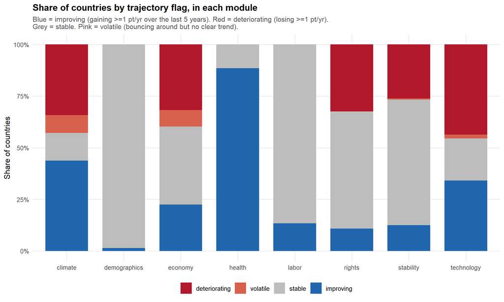

```r
flag_dist <- trajectories |>
  filter(flag != "insufficient_data") |>
  count(module, flag) |>
  group_by(module) |>
  mutate(share = n / sum(n)) |>
  ungroup() |>
  mutate(flag = factor(flag, levels = c("deteriorating", "volatile", "stable", "improving")))

ggplot(flag_dist, aes(module, share, fill = flag)) +
  geom_col(position = "stack", width = 0.75) +
  scale_y_continuous(labels = percent_format()) +
  scale_fill_manual(values = c(
    deteriorating = "#b2182b",
    volatile      = "#d6604d",
    stable        = "#bdbdbd",
    improving     = "#2166ac"
  )) +
  labs(
    title    = "Share of countries by trajectory flag, in each module",
    subtitle = "Blue = improving (gaining >=1 pt/yr over the last 5 years). Red = deteriorating (losing >=1 pt/yr).\nGrey = stable. Pink = volatile (bouncing around but no clear trend).",
    x = NULL, y = "Share of countries", fill = NULL
  ) +
  theme_lp()
```

## C5.3 “Level vs trend” — where countries are, and where they are going

For a single module at a time, this chart shows where each country currently stands (horizontal axis) versus how fast it’s moving (vertical axis). It puts the two most important pieces of information in one place.

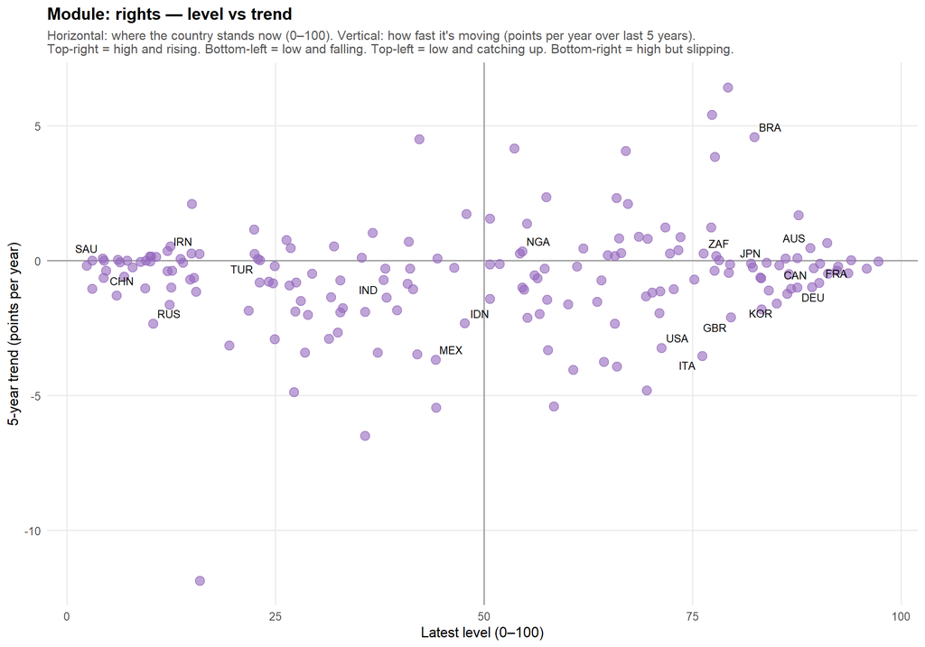

```r
plot_slope_level <- function(target_module) {
  d <- trajectories |>
    filter(module == target_module, !is.na(trend_5y), !is.na(level), n_years_5y >= 4)

  ggplot(d, aes(level, trend_5y)) +
    geom_hline(yintercept = 0, color = "grey60") +
    geom_vline(xintercept = 50, color = "grey60") +
    geom_point(aes(size = n_years_5y), color = MODULE_COLORS[[target_module]], alpha = 0.6) +
    ggrepel::geom_text_repel(
      data = d |> filter(country_iso3 %in% c("USA","CHN","IND","DEU","JPN","GBR","BRA",
                                             "RUS","ZAF","NGA","SAU","IRN","TUR",
                                             "MEX","IDN","KOR","FRA","ITA","CAN","AUS")),
      aes(label = country_iso3), size = 3, max.overlaps = 30
    ) +
    scale_size_continuous(range = c(1.5, 4), guide = "none") +
    labs(
      title    = paste("Module:", target_module, "— level vs trend"),
      subtitle = "Horizontal: where the country stands now (0–100). Vertical: how fast it's moving (points per year over last 5 years).\nTop-right = high and rising. Bottom-left = low and falling. Top-left = low and catching up. Bottom-right = high but slipping.",
      x = "Latest level (0–100)",
      y = "5-year trend (points per year)"
    ) +
    theme_lp()
}

plot_slope_level("rights")
```

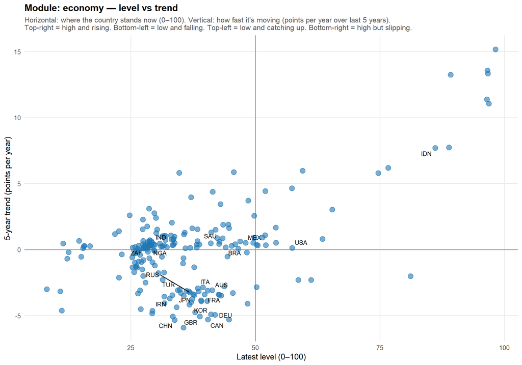

```r
plot_slope_level("economy")
```

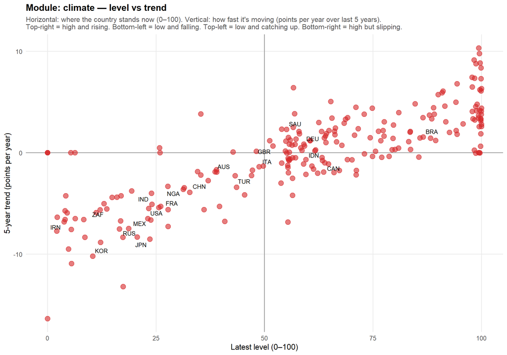

```r
plot_slope_level("climate")
```

- **Top-right (high level, rising)**: doing well and getting better. The “good news” quadrant.
- **Top-left (low level, rising)**: catching up. The “convergence” quadrant — a poor country making real gains.
- **Bottom-left (low level, falling)**: doing badly and getting worse. The “crisis” quadrant.
- **Bottom-right (high level, falling)**: established but slipping. This is the quadrant that contains most of the alarming democratic-backsliding stories.

For **rights**, this run shows established democracies (USA, France, Germany, UK) clustered in the bottom-right quadrant — high level, declining slope. That is the V-Dem democratic-recession finding showing up directly in this notebook’s own analysis.

For **economy**, treat the horizontal axis with the skepticism that C2.2 demands.

# C6. Profile of a single country

This last section is a **template**. You set one variable — `target_country` — to any country’s ISO3 code, and the rest of the section generates a focused profile.

```r
target_country <- "USA"   # change to any ISO3 code: DEU, JPN, IND, BRA, NGA, ...
```

## C6.1 Where does USA stand on each module?

This chart compares USA to every other country in the world, module by module. For each module, the **grey bar** shows where the middle 80% of all countries fall (from the 10th to the 90th percentile), the **short grey tick** marks the global median, and the **colored dot** is USA’s score.

A dot in the middle of the grey bar means USA is about average. A dot to the right of the bar means it is in the top 10% of the world. A dot to the left means it is in the bottom 10%.

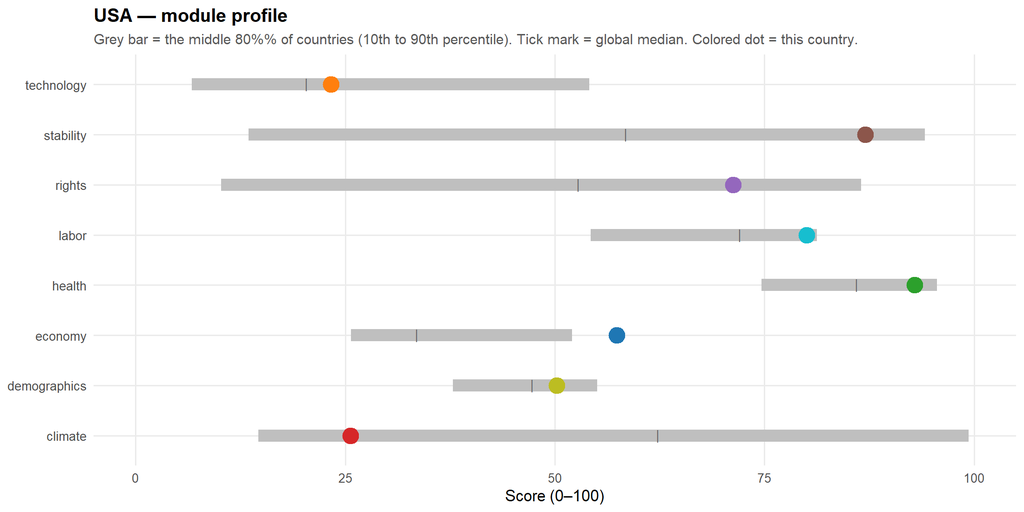

```r
country_latest <- latest_scores |>
  filter(country_iso3 == target_country)

global_summary <- latest_scores |>
  group_by(module) |>
  summarise(
    p10 = quantile(score_pct_fixed, 0.10, na.rm = TRUE),
    p50 = median(score_pct_fixed,     na.rm = TRUE),
    p90 = quantile(score_pct_fixed, 0.90, na.rm = TRUE),
    .groups = "drop"
  )

profile <- global_summary |>
  left_join(country_latest |> select(module, country_score = score_pct_fixed, coverage),
            by = "module")

ggplot(profile, aes(y = module)) +
  geom_segment(aes(x = p10, xend = p90, yend = module), color = "grey75", linewidth = 4) +
  geom_point(aes(x = p50), color = "grey40", size = 3, shape = "|") +
  geom_point(aes(x = country_score, color = module), size = 5) +
  scale_color_manual(values = MODULE_COLORS, guide = "none") +
  scale_x_continuous(limits = c(0, 100)) +
  labs(
    title    = paste(target_country, "— module profile"),
    subtitle = "Grey bar = the middle 80%% of countries (10th to 90th percentile). Tick mark = global median. Colored dot = this country.",
    x        = "Score (0–100)", y = NULL
  ) +
  theme_lp()
```

## C6.2 How USA has moved over time

Each panel below shows one module’s score for USA across all years, with a dashed line showing the trend over the last 5 years (the same trend that fed the trajectory flag).

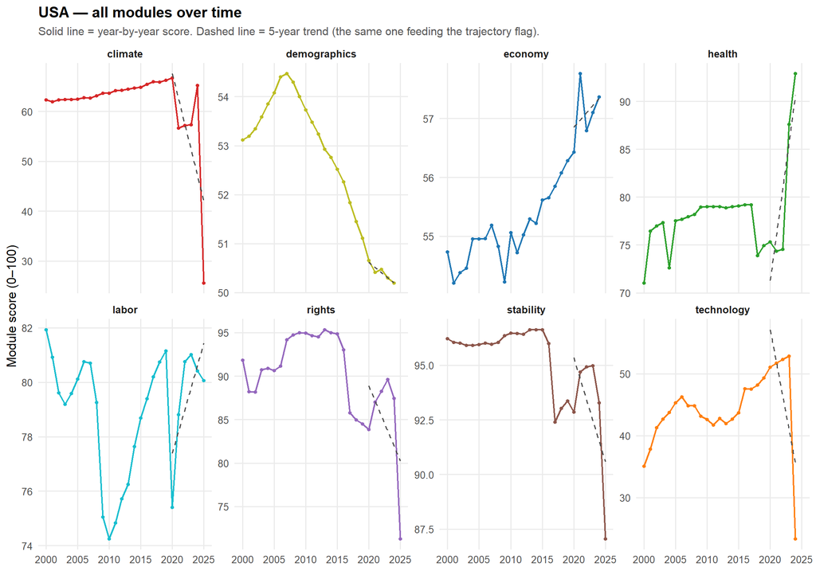

```r
country_ts <- scores |>
  filter(country_iso3 == target_country)

ggplot(country_ts, aes(year, score_pct_fixed)) +
  geom_line(aes(color = module), linewidth = 0.7) +
  geom_point(aes(color = module), size = 1) +
  geom_smooth(method = "lm", se = FALSE, linetype = "dashed",
              color = "grey30", linewidth = 0.5,
              data = ~ filter(.x, year >= latest_year - 5)) +
  facet_wrap(~ module, ncol = 4, scales = "free_y") +
  scale_x_continuous(limits = c(ANALYSIS_START_YEAR, max(country_ts$year))) +
  scale_color_manual(values = MODULE_COLORS, guide = "none") +
  labs(
    title    = paste(target_country, "— all modules over time"),
    subtitle = "Solid line = year-by-year score. Dashed line = 5-year trend (the same one feeding the trajectory flag).",
    x        = NULL, y = "Module score (0–100)"
  ) +
  theme_lp()
```

A few common patterns to look for in any country’s profile:

- A **steady rise** across most modules — the development story of a country pulling itself up over time.
- A **single steep drop in one module** — usually identifies a crisis (financial collapse, war, coup) localized to that domain.
- A **broad simultaneous dip in 2020–2021** — almost certainly the COVID pandemic.
- A **sharp cliff in the last 1–2 years** — almost always reporting lag, not a real event.

## C6.3 Diving into the weakest module

When a country scores low on a module, the natural next question is: **why?** What’s dragging the score down? This chart breaks the lowest-scoring module into its individual indicators.

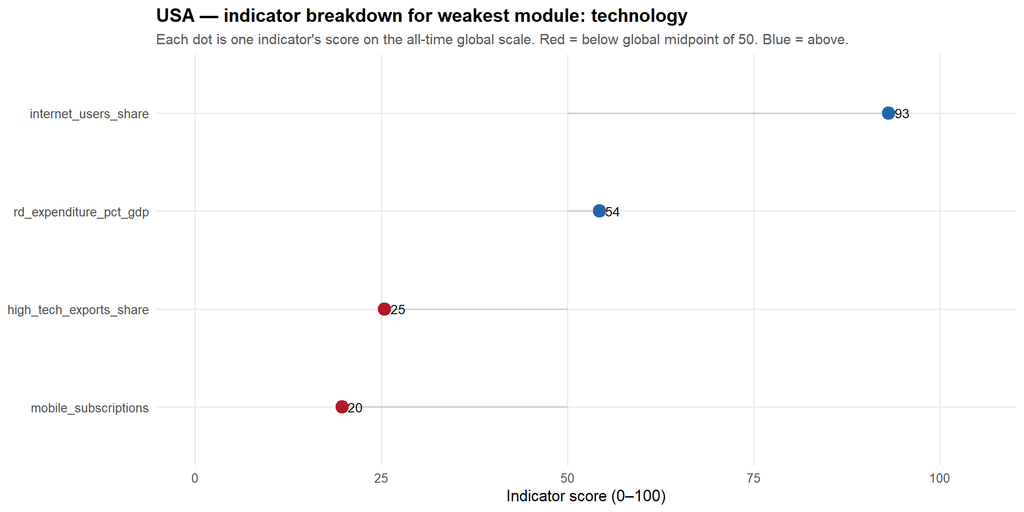

```r
weakest <- country_latest |> slice_min(score_pct_fixed, n = 1) |> pull(module)

drilldown <- normalized |>
  left_join(indicators |> select(indicator, module), by = "indicator") |>
  filter(country_iso3 == target_country,
         module == weakest,
         year >= latest_year - 2) |>
  group_by(indicator) |>
  slice_max(year, n = 1, with_ties = FALSE) |>
  ungroup() |>
  arrange(pct_fixed)

ggplot(drilldown, aes(x = pct_fixed, y = reorder(indicator, pct_fixed))) +
  geom_segment(aes(xend = 50, yend = indicator), color = "grey80") +
  geom_point(aes(color = pct_fixed < 50), size = 4) +
  geom_text(aes(label = sprintf("%.0f", pct_fixed)),
            hjust = -0.4, size = 3.2) +
  scale_color_manual(values = c(`TRUE` = "#b2182b", `FALSE` = "#2166ac"), guide = "none") +
  scale_x_continuous(limits = c(0, 105)) +
  labs(
    title    = paste(target_country, "— indicator breakdown for weakest module:", weakest),
    subtitle = "Each dot is one indicator's score on the all-time global scale. Red = below global midpoint of 50. Blue = above.",
    x        = "Indicator score (0–100)",
    y        = NULL
  ) +
  theme_lp()
```

This drill-down is the most useful diagnostic tool when a module score surprises you. **Worked example: the USA’s technology module in this run** — the country comes out with a mediocre technology score, which is counter-intuitive. Drilling in shows:

- `internet_users_share = 93` (very high — sane).
- `rd_expenditure_pct_gdp = 54` (around average — sane).
- `mobile_subscriptions = 20` (USA at about 120 per 100 people, but the all-time global maximum is 574 — see C2.2 — so the USA gets unfairly scaled to 20).
- `high_tech_exports_share = 25` (USA exports enormous absolute volumes of high-tech goods, but they’re a small *share* of its diverse manufacturing mix — see C2.3; this is the wrong proxy for tech leadership in large economies).

So the USA’s “low” technology module score is **not a real signal about US technological capability**. It is the model’s broken indicators showing up. Looking at the indicator-by-indicator breakdown is the only way to catch this.

## C6.4 Comparing with peer countries

Lastly, how does USA compare to a chosen peer group on its weakest module?

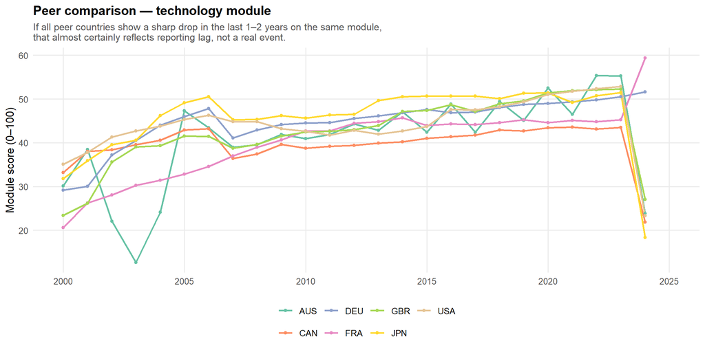

```r
peers <- c("USA", "DEU", "JPN", "GBR", "FRA", "CAN", "AUS")  # edit as desired
peer_module <- weakest

scores |>
  filter(country_iso3 %in% peers, module == peer_module) |>
  ggplot(aes(year, score_pct_fixed, color = country_iso3)) +
  geom_line(linewidth = 0.9) +
  geom_point(size = 1.2) +
  scale_x_continuous(limits = c(ANALYSIS_START_YEAR, latest_year)) +
  scale_color_brewer(palette = "Set2", name = NULL) +
  labs(
    title    = paste("Peer comparison —", peer_module, "module"),
    subtitle = "If all peer countries show a sharp drop in the last 1–2 years on the same module,\nthat almost certainly reflects reporting lag, not a real event.",
    x = NULL, y = "Module score (0–100)"
  ) +
  theme_lp()
```

# Part D — What this model cannot do

A careful reader at this point should feel two things:

1. The pipeline is **doing real work**. The V-Dem-based modules are producing reasonable rankings and capturing real-world trends (democratic backsliding). The health module is picking up the genuine global improvement in longevity and child survival.
2. The pipeline is **not finished**. Several modules have known bugs that produce technically-correct but misleading numbers.

This section is honest about both.

# D1. Known active issues in this run

These are bugs the diagnostics in Parts B and C have already surfaced. They are listed here in roughly the order they should be fixed.

| Issue | Where it lives | What it would take to fix |
| --- | --- | --- |
| OWID datasets contain data going back to 1789, which is included in the scaling range. | OWID fetch and combine scripts. | Restrict the date range either at fetch time or right after loading. The notebook currently filters defensively. |
| Min-max scaling crushes most countries on heavy-tailed indicators (CO2, inflation, mobile subscriptions). | `helpers.R::normalize_indicators`. | Add a `transform` column to `indicators.csv` (values: `none`, `log`, `winsorize`) and respect it during scaling. |
| The economy module rewards small, poor countries with sparse data. | Indicator choices + outlier-driven scaling. | Same as above, plus reconsider whether low income inequality should be rewarded in low-wealth contexts. |
| Demographics indicators are anti-correlated within the module. | Module composition. | Drop the `demographics` *score*. Keep the indicators as context. |
| `mobile_subscriptions` has a 574-per-100 outlier (Macau / Hong Kong tourist roaming). | Raw World Bank data. | Winsorize during the scaling step. |
| `high_tech_exports_share` rewards specialization, not capability. Large, diversified manufacturers like the USA score poorly. | Indicator choice. | Replace with absolute R&D spending in PPP terms or patents per capita. |
| Trajectory flag is contaminated by reporting lag. | `helpers.R::compute_trajectories`. | Either require coverage to be stable across the 5-year window, or compute trends only on a fixed indicator subset. |
| `rights` and `stability` modules are highly redundant (both are V-Dem). | Module design. | Merge them into a single `governance` module, or add a true stability source (UCDP conflict data) to differentiate them. |

Most of these fixes are small and localized. None of them require re-architecting the pipeline.

# D2. What this model is not equipped to do at all

The original framing of the project mentioned three eventual steps: build a world model (Step 1), predict future trends (Step 2), and project individual life paths (Step 3). This notebook is part of Step 1. The other two are **substantially out of reach** with the current setup, and being honest about why is important.

## D2.1 Why this is not a forecast

This is a **descriptive** model, not a predictive one. It tells you where countries are and where they have recently been. It does not say where they are going next year.

To do real forecasting, several things would have to change:

- The trajectory flag is just a straight line drawn through the last five years. That is fine as a description. It is not a prediction — straight lines extrapolated forward almost never match what actually happens.
- Real time-series forecasting uses models that can capture non-linear movement, sudden shocks, and uncertainty bands (techniques with names like ARIMA and state-space models). None of those are used here.
- All of our current indicators are *lagging* — they report what has already happened. Real prediction needs *leading* indicators — early signs of change. We don’t have those.
- We have no event data. Wars, coups, financial crises, and pandemics are absent from our inputs. They are the most important things to predict. UCDP and EM-DAT would help.
- We don’t model how countries affect each other. A recession in China is not independent from one in South Korea. Our trajectory computation treats each country in isolation.

## D2.2 Why this cannot project individual life paths

Country-level scorecards are **priors** on individual outcomes, not predictions of them. Knowing a country has good healthcare on average doesn’t tell you whether *one particular person* will get good healthcare; it just shifts the odds.

To go from country-level scorecards to a usable picture of how an individual life might unfold, you would additionally need:

- Distributions of individual outcomes *within* each country — what fraction of people achieve a given income, education, life expectancy, etc. Datasets like the Demographic and Health Surveys, the Gallup World Poll, and OECD’s Better Life Index contain this.
- A probabilistic framework that maps country-level inputs to individual-outcome distributions, with the right uncertainty attached.
- Honesty that the output is then **a range of informed scenarios, not predictions**. There is no responsible way to tell an individual person what will happen to them based on country-level data alone.

# D3. The trustworthy parts

Despite the caveats above, several parts of this pipeline are trustworthy *as descriptive instruments*:

- **The V-Dem-based modules (`rights` and `stability`)** are producing rankings that match well-established findings in political science. The democratic-backsliding trend visible in this notebook’s own data is consistent with how V-Dem itself reports it.
- **The health module** captures the long, robust global trend of improving life expectancy and falling infant mortality.
- **The data infrastructure** — the panel, the coverage tracking, the trajectory summary — is solid. The bugs are in indicator selection and scaling, not in the structure.

That structure is the foundation for everything else. Once the indicator-level fixes in D1 are made, the rest of the pipeline does not need to change.

# E1. The files this notebook reads

| File | Produced by | Rows in this run | What it is |
| --- | --- | --- | --- |
| `data/output/country_year_indicators.csv` | `02_combine_process.R` | 439,321 raw → 181,837 post-filter | Long panel of indicator-level data: country, year, indicator, raw value, and the two scaled columns. Metadata (module, unit, direction, source) is in `indicators.csv` — joined on as needed. |
| `data/output/country_year_scores.csv` | `02_combine_process.R` | 111,386 | Module composites with coverage flag. |
| `data/output/country_trajectories.csv` | `02_combine_process.R` | 1,632 | One row per country-module: level, trend, flag. |
| `config/indicators.csv` | hand-maintained | 43 | The indicator registry — one row per indicator, including its source, module, direction, and weight within its module. |

# E2. Glossary

For the non-technical reader, the small set of terms used in this notebook:

- **Country panel / panel data** — A table where every row is a combination of a country and a year (and possibly a measurement).
- **Indicator** — One specific measurable thing about a country (life expectancy, GDP per person, etc.).
- **Module** — A grouping of related indicators into a thematic scorecard subject (economy, health, rights, etc.).
- **ISO3 code** — The standard three-letter code for a country (USA, DEU, JPN, …). Used everywhere instead of country names to avoid mismatches.
- **`pct_global`** — A score 0–100 saying where a country ranks against others *this year* on one indicator. 50 = exactly the median country.
- **`pct_fixed`** — A score 0–100 saying where a country sits on the *all-time global scale* for one indicator. 0 = matches the all-time global worst, 100 = matches the all-time global best.
- **Direction** — Whether the original indicator is “higher is better” (like life expectancy) or “lower is better” (like infant mortality). After scaling, we flip the lower-is-better ones so higher = better everywhere.
- **Weighted average** — An average where some inputs count more than others. Used to combine an indicator’s scores into a module score.
- **Coverage** — The share of a module’s expected indicators that are actually available for a given country-year. Low coverage means the score is computed from less information.
- **Trend (5-year)** — The slope of the line that best fits the last five years of scores. Measured in points per year.
- **Volatility** — How much the score is bouncing around year-to-year, measured as the standard deviation over the last five years.
- **Flag** — One of `improving`, `deteriorating`, `volatile`, `stable`, or `insufficient_data`, summarising the trajectory.
- **Correlation (r)** — A number from −1 to +1 measuring how closely two indicators move together. +1 = perfectly together, 0 = unrelated, −1 = perfectly opposite.
- **Outlier** — A single extreme value sitting far away from the rest of the data. Outliers are dangerous for min-max scaling because they anchor the upper limit far away from where most countries actually are.
- **Reporting lag** — The simple fact that countries publish their statistics with a delay, so the most recent 1–2 years always look thinner than older years.

# E3. Where to look first if something looks wrong

The pipeline writes a small text file at `data/output/quality_report.txt`. It is generated automatically every time the processing scripts run, and it records sanity-check results (no duplicates, no bad years, no out-of-bounds scaled values, sufficient country coverage, etc.). If any chart in this notebook looks broken, that text file is the first place to look.